# Single seed microbiota: assembly and transmission from parent plant to seedling

## 8.2 - Bacterial richness

We then compared bacterial richness in each habitat

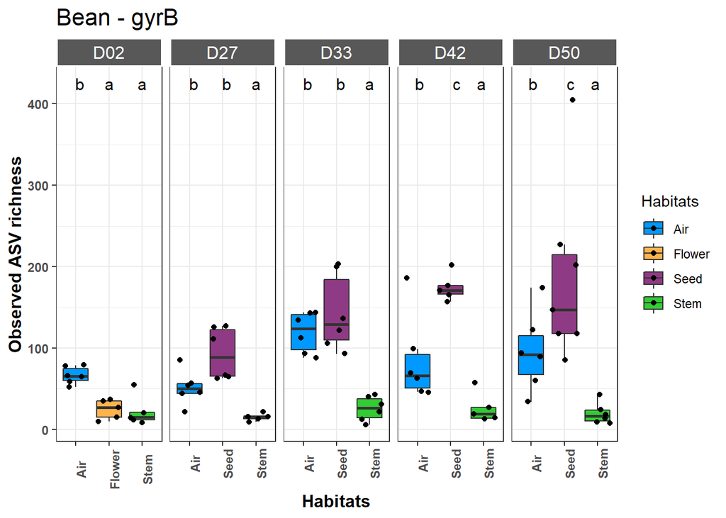

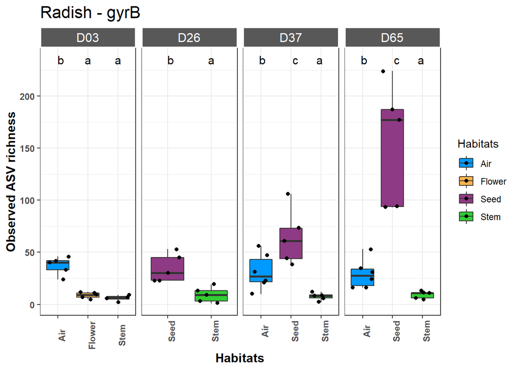

## 8.3 - Beta-diversity

We measured phylogenetic similarities between habitats (Flower, Stem and Air) and plants over time. We performed a log(1+x) transformation and assess wUF distance.

Calculate weighted UniFrac distance

Ordination

### 8.3.1 - Permanova (Airborne community)

We first assessed impact on DAP and plant-species on air-borne community through PERMANOVA.

```r
log.agg.16S.air <- subset_samples(log.agg.16S, Habitats == "Air")
log.agg.16S.air <- filter_taxa(log.agg.16S.air, function(x) sum (x)>0, TRUE) # 629 taxa and 47 samples
log.agg.gyrB.air <- subset_samples(log.agg.gyrB, Habitats == "Air")
log.agg.gyrB.air <- filter_taxa(log.agg.gyrB.air, function(x) sum (x)>0, TRUE) # 1781 taxa and 47 samples
mdat.16S.air <- as(sample_data(log.agg.16S.air), "data.frame")
wUF.16S.air <- phyloseq::distance(log.agg.16S.air, method = "wunifrac")
adonis.16S.air <- adonis2(wUF.16S.air ~ Plant_species * DAP,
                                data = mdat.16S.air, perm = 999)
print(adonis.16S.air)
```

```
## Permutation test for adonis under reduced model
## Terms added sequentially (first to last)
## Permutation: free
## Number of permutations: 999
##
## adonis2(formula = wUF.16S.air ~ Plant_species * DAP, data = mdat.16S.air, permutations = 999)
##               Df SumOfSqs      R2       F Pr(>F)
## Plant_species  1   0.5789 0.15621 13.2511  0.001 ***
## DAP            6   1.4232 0.38403  5.4294  0.001 ***
## Residual      39   1.7038 0.45976
## Total         46   3.7060 1.00000
## ---
## Signif. codes:  0 '***' 0.001 '**' 0.01 '*' 0.05 '.' 0.1 ' ' 1
```

```r
mdat.gyrB.air <- as(sample_data(log.agg.gyrB.air), "data.frame")
wUF.gyrB.air <- phyloseq::distance(log.agg.gyrB.air, method = "wunifrac")
adonis.gyrB.air <- adonis2(wUF.gyrB.air ~ Plant_species * DAP,
                                data = mdat.gyrB.air, perm = 999)
print(adonis.gyrB.air)
```

```
## Permutation test for adonis under reduced model
## Terms added sequentially (first to last)
## Permutation: free
## Number of permutations: 999
##
## adonis2(formula = wUF.gyrB.air ~ Plant_species * DAP, data = mdat.gyrB.air, permutations = 999)
##               Df SumOfSqs      R2      F Pr(>F)
## Plant_species  1   0.6035 0.12469 9.2527  0.001 ***
## DAP            6   1.6928 0.34974 4.3255  0.001 ***
## Residual      39   2.5438 0.52557
## Total         46   4.8400 1.00000
## ---
## Signif. codes:  0 '***' 0.001 '**' 0.01 '*' 0.05 '.' 0.1 ' ' 1
```

### 8.3.2 - Permanova (Stem/Seeds communities)

We next assessed the impact of DAP on stem and seed communities with PERMANOVA First we subset the dataset in bean and radish before running PERMANOVA.

```r
log.agg.16S.bean <- subset_samples(log.agg.16S, Plant_species == "Bean")
log.agg.16S.bean <- filter_taxa(log.agg.16S.bean, function(x) sum (x)>0, TRUE) # 1499 taxa and 86 samples
log.agg.16S.rad <- subset_samples(log.agg.16S, Plant_species == "Radish")
log.agg.16S.rad <- filter_taxa(log.agg.16S.rad, function(x) sum (x)>0, TRUE) # 764 taxa and 55 samples
log.agg.gyrB.bean <- subset_samples(log.agg.gyrB, Plant_species == "Bean")
log.agg.gyrB.bean <- filter_taxa(log.agg.gyrB.bean, function(x) sum (x)>0, TRUE) # 3358 taxa and 86 samples
log.agg.gyrB.rad <- subset_samples(log.agg.gyrB, Plant_species == "Radish")
log.agg.gyrB.rad <- filter_taxa(log.agg.gyrB.rad, function(x) sum (x)>0, TRUE) # 1261 taxa and 56 samples
```

```r
library(vegan)
mdat.16S.bean <- as(sample_data(log.agg.16S.bean), "data.frame")
wUF.16S.bean <- phyloseq::distance(log.agg.16S.bean, method = "wunifrac")
adonis.16S.bean <- adonis2(wUF.16S.bean ~ Stage * Habitats,
                                data = mdat.16S.bean, perm = 999)
print(adonis.16S.bean)
```

```
## Permutation test for adonis under reduced model
## Terms added sequentially (first to last)
## Permutation: free
## Number of permutations: 999
##
## adonis2(formula = wUF.16S.bean ~ Stage * Habitats, data = mdat.16S.bean, permutations = 999)
##                Df SumOfSqs      R2      F Pr(>F)
## Stage           4   1.2350 0.17118 5.5578  0.001 ***
## Habitats        3   1.1149 0.15453 6.6895  0.001 ***
## Stage:Habitats  7   0.9204 0.12757 2.3668  0.001 ***
## Residual       71   3.9443 0.54671
## Total          85   7.2145 1.00000
## ---
## Signif. codes:  0 '***' 0.001 '**' 0.01 '*' 0.05 '.' 0.1 ' ' 1
```

Strong interaction between Stage and Habitats we then subset by Habitat to assess the relative important of stage in each Habitat.

```r
log.16S.bean.stem <- subset_samples(log.agg.16S.bean, Habitats == "Stem")
log.16S.bean.stem <- filter_taxa(log.16S.bean.stem, function(x) sum (x)>0, TRUE) # 236 taxa and 27 samples
log.16S.bean.seed <- subset_samples(log.agg.16S.bean, Habitats == "Seed")
log.16S.bean.seed <- filter_taxa(log.16S.bean.seed, function(x) sum (x)>0, TRUE) # 1038 taxa and 24 samples
log.16S.rad.stem <- subset_samples(log.agg.16S.rad, Habitats == "Stem")
log.16S.rad.stem <- filter_taxa(log.16S.rad.stem, function(x) sum (x)>0, TRUE) # 88 taxa and 18 samples
log.16S.rad.seed <- subset_samples(log.agg.16S.rad, Habitats == "Seed")
log.16S.rad.seed <- filter_taxa(log.16S.rad.seed, function(x) sum (x)>0, TRUE) # 594 taxa and 15 samples

log.gyrB.bean.stem <- subset_samples(log.agg.gyrB.bean, Habitats == "Stem")
log.gyrB.bean.stem <- filter_taxa(log.gyrB.bean.stem, function(x) sum (x)>0, TRUE) # 453 taxa and 27 samples
log.gyrB.bean.seed <- subset_samples(log.agg.gyrB.bean, Habitats == "Seed")
log.gyrB.bean.seed <- filter_taxa(log.gyrB.bean.seed, function(x) sum (x)>0, TRUE) # 1955 taxa and 24 samples
log.gyrB.rad.stem <- subset_samples(log.agg.gyrB.rad, Habitats == "Stem")
log.gyrB.rad.stem <- filter_taxa(log.gyrB.rad.stem, function(x) sum (x)>0, TRUE) # 110 taxa and 19 samples
log.gyrB.rad.seed <- subset_samples(log.agg.gyrB.rad, Habitats == "Seed")
log.gyrB.rad.seed <- filter_taxa(log.gyrB.rad.seed, function(x) sum (x)>0, TRUE) # 851 taxa and 15 sample
```

```r
library(vegan)
mdat.16S.bean.stem <- as(sample_data(log.16S.bean.stem), "data.frame")
wUF.16S.bean.stem <- phyloseq::distance(log.16S.bean.stem, method = "wunifrac")
adonis.16S.bean.stem <- adonis2(wUF.16S.bean.stem ~ Stage,
                                data = mdat.16S.bean.stem, perm = 999)
print(adonis.16S.bean.stem)
```

```
## Permutation test for adonis under reduced model
## Terms added sequentially (first to last)
## Permutation: free
## Number of permutations: 999
##
## adonis2(formula = wUF.16S.bean.stem ~ Stage, data = mdat.16S.bean.stem, permutations = 999)
##          Df SumOfSqs     R2      F Pr(>F)
## Stage     4  0.63857 0.2223 1.5721  0.071 .
## Residual 22  2.23399 0.7777
## Total    26  2.87256 1.0000
## ---
## Signif. codes:  0 '***' 0.001 '**' 0.01 '*' 0.05 '.' 0.1 ' ' 1
```

```r
mdat.gyrB.bean.stem <- as(sample_data(log.gyrB.bean.stem), "data.frame")
wUF.gyrB.bean.stem <- phyloseq::distance(log.gyrB.bean.stem, method = "wunifrac")
adonis.gyrB.bean.stem <- adonis2(wUF.gyrB.bean.stem ~ Stage,
                                data = mdat.gyrB.bean.stem, perm = 999)
print(adonis.gyrB.bean.stem)
```

```
## Permutation test for adonis under reduced model
## Terms added sequentially (first to last)
## Permutation: free
## Number of permutations: 999
##
## adonis2(formula = wUF.gyrB.bean.stem ~ Stage, data = mdat.gyrB.bean.stem, permutations = 999)
##          Df SumOfSqs      R2      F Pr(>F)
## Stage     4  0.54437 0.22681 1.6134  0.019 *
## Residual 22  1.85572 0.77319
## Total    26  2.40010 1.00000
## ---
## Signif. codes:  0 '***' 0.001 '**' 0.01 '*' 0.05 '.' 0.1 ' ' 1
```

```r
mdat.16S.bean.seed <- as(sample_data(log.16S.bean.seed), "data.frame")
wUF.16S.bean.seed <- phyloseq::distance(log.16S.bean.seed, method = "wunifrac")
adonis.16S.bean.seed <- adonis2(wUF.16S.bean.seed ~ Stage,
                                data = mdat.16S.bean.seed, perm = 999)
print(adonis.16S.bean.seed)
```

```
## Permutation test for adonis under reduced model
## Terms added sequentially (first to last)
## Permutation: free
## Number of permutations: 999
##
## adonis2(formula = wUF.16S.bean.seed ~ Stage, data = mdat.16S.bean.seed, permutations = 999)
##          Df SumOfSqs   R2      F Pr(>F)
## Stage     3  0.32592 0.41 4.6327  0.001 ***
## Residual 20  0.46901 0.59
## Total    23  0.79493 1.00
## ---
## Signif. codes:  0 '***' 0.001 '**' 0.01 '*' 0.05 '.' 0.1 ' ' 1
```

```r
mdat.gyrB.bean.seed <- as(sample_data(log.gyrB.bean.seed), "data.frame")
wUF.gyrB.bean.seed <- phyloseq::distance(log.gyrB.bean.seed, method = "wunifrac")
adonis.gyrB.bean.seed <- adonis2(wUF.gyrB.bean.seed ~ Stage,
                                data = mdat.gyrB.bean.seed, perm = 999)
print(adonis.gyrB.bean.seed)
```

```
## Permutation test for adonis under reduced model
## Terms added sequentially (first to last)
## Permutation: free
## Number of permutations: 999
##
## adonis2(formula = wUF.gyrB.bean.seed ~ Stage, data = mdat.gyrB.bean.seed, permutations = 999)
##          Df SumOfSqs      R2     F Pr(>F)
## Stage     3  0.19352 0.38898 4.244  0.001 ***
## Residual 20  0.30399 0.61102
## Total    23  0.49751 1.00000
## ---
## Signif. codes:  0 '***' 0.001 '**' 0.01 '*' 0.05 '.' 0.1 ' ' 1
```

```r
mdat.16S.rad.stem <- as(sample_data(log.16S.rad.stem), "data.frame")
wUF.16S.rad.stem <- phyloseq::distance(log.16S.rad.stem, method = "wunifrac")
adonis.16S.rad.stem <- adonis2(wUF.16S.rad.stem ~ Stage,
                                data = mdat.16S.rad.stem, perm = 999)
print(adonis.16S.rad.stem)
```

```
## Permutation test for adonis under reduced model
## Terms added sequentially (first to last)
## Permutation: free
## Number of permutations: 999
##
## adonis2(formula = wUF.16S.rad.stem ~ Stage, data = mdat.16S.rad.stem, permutations = 999)
##          Df SumOfSqs      R2      F Pr(>F)
## Stage     3   0.4789 0.13204 0.7099  0.744
## Residual 14   3.1482 0.86796
## Total    17   3.6272 1.00000
```

```r
mdat.gyrB.rad.stem <- as(sample_data(log.gyrB.rad.stem), "data.frame")
wUF.gyrB.rad.stem <- phyloseq::distance(log.gyrB.rad.stem, method = "wunifrac")
adonis.gyrB.rad.stem <- adonis2(wUF.gyrB.rad.stem ~ Stage,
                                data = mdat.gyrB.rad.stem, perm = 999)
print(adonis.gyrB.rad.stem)
```

```
## Permutation test for adonis under reduced model
## Terms added sequentially (first to last)
## Permutation: free
## Number of permutations: 999
##
## adonis2(formula = wUF.gyrB.rad.stem ~ Stage, data = mdat.gyrB.rad.stem, permutations = 999)
##          Df SumOfSqs      R2      F Pr(>F)
## Stage     3  0.44034 0.21453 1.3656  0.044 *
## Residual 15  1.61226 0.78547
## Total    18  2.05260 1.00000
## ---
## Signif. codes:  0 '***' 0.001 '**' 0.01 '*' 0.05 '.' 0.1 ' ' 1
```

```r
mdat.16S.rad.seed <- as(sample_data(log.16S.rad.seed), "data.frame")
wUF.16S.rad.seed <- phyloseq::distance(log.16S.rad.seed, method = "wunifrac")
adonis.16S.rad.seed <- adonis2(wUF.16S.rad.seed ~ Stage,
                                data = mdat.16S.rad.seed, perm = 999)
print(adonis.16S.rad.seed)
```

```
## Permutation test for adonis under reduced model
## Terms added sequentially (first to last)
## Permutation: free
## Number of permutations: 999
##
## adonis2(formula = wUF.16S.rad.seed ~ Stage, data = mdat.16S.rad.seed, permutations = 999)
##          Df SumOfSqs      R2      F Pr(>F)
## Stage     2  0.27391 0.37524 3.6037  0.002 **
## Residual 12  0.45604 0.62476
## Total    14  0.72994 1.00000
## ---
## Signif. codes:  0 '***' 0.001 '**' 0.01 '*' 0.05 '.' 0.1 ' ' 1
```

```r
mdat.gyrB.rad.seed <- as(sample_data(log.gyrB.rad.seed), "data.frame")
wUF.gyrB.rad.seed <- phyloseq::distance(log.gyrB.rad.seed, method = "wunifrac")
adonis.gyrB.rad.seed <- adonis2(wUF.gyrB.rad.seed ~ Stage,
                                data = mdat.gyrB.rad.seed, perm = 999)
print(adonis.gyrB.rad.seed)
```

```
## Permutation test for adonis under reduced model
## Terms added sequentially (first to last)
## Permutation: free
## Number of permutations: 999
##
## adonis2(formula = wUF.gyrB.rad.seed ~ Stage, data = mdat.gyrB.rad.seed, permutations = 999)
##          Df SumOfSqs      R2      F Pr(>F)
## Stage     2  0.15681 0.30752 2.6645  0.001 ***
## Residual 12  0.35309 0.69248
## Total    14  0.50990 1.00000
## ---
## Signif. codes:  0 '***' 0.001 '**' 0.01 '*' 0.05 '.' 0.1 ' ' 1
```

## 8.4 Taxonomic composition

Taxonomic composition evaluated for each source habitat sampled at each stage of development.

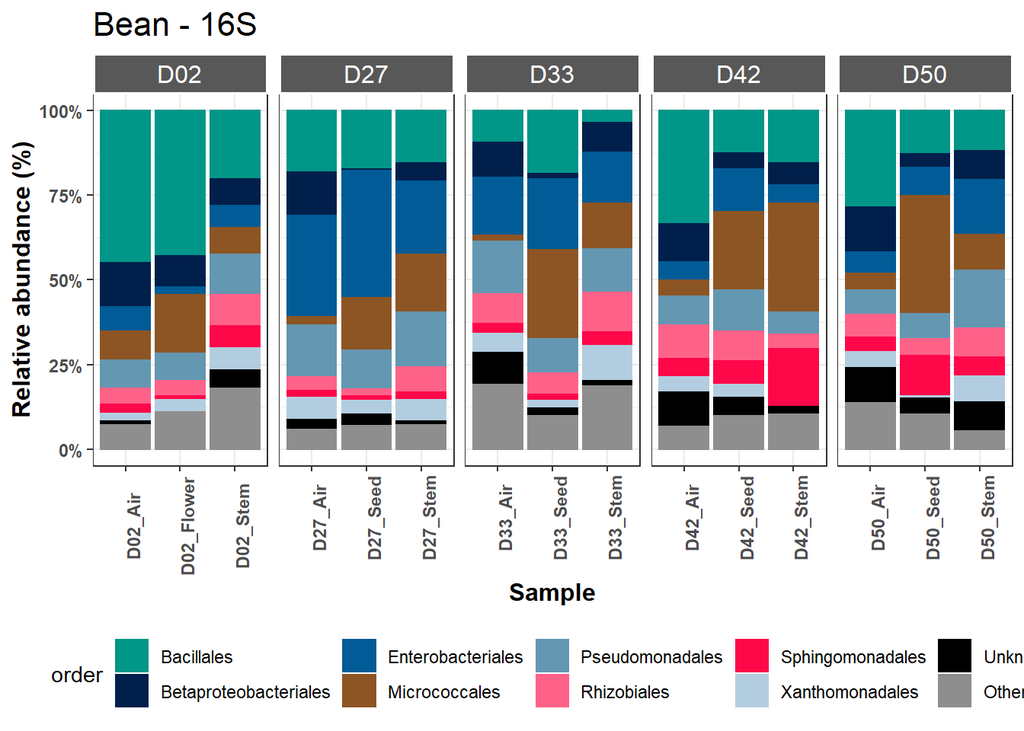

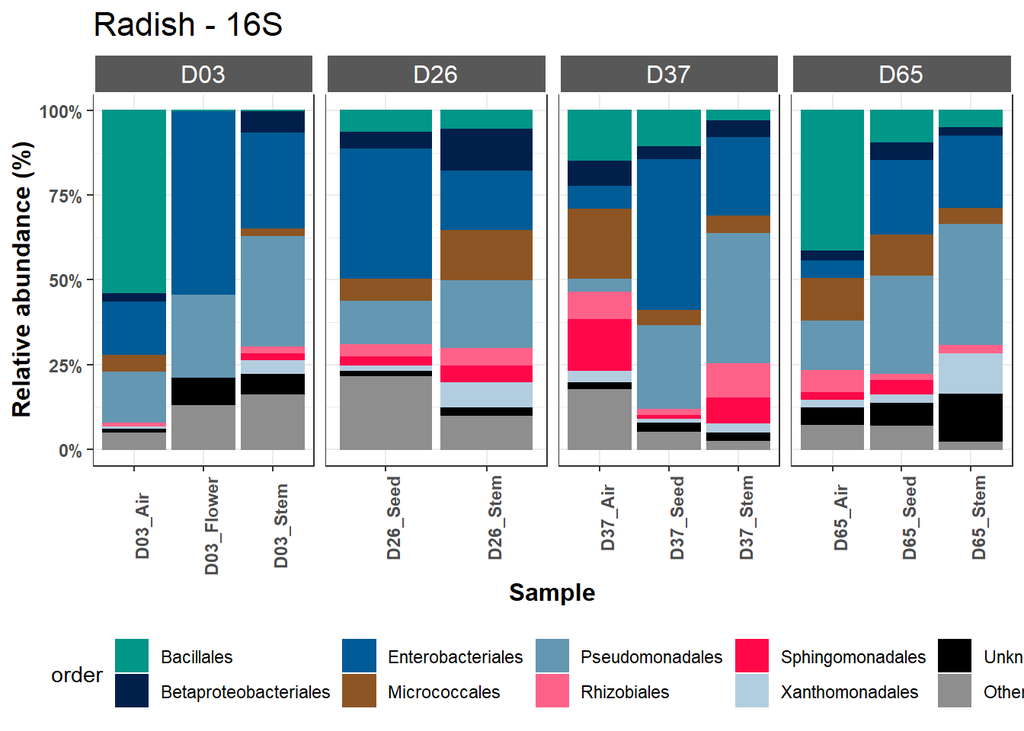

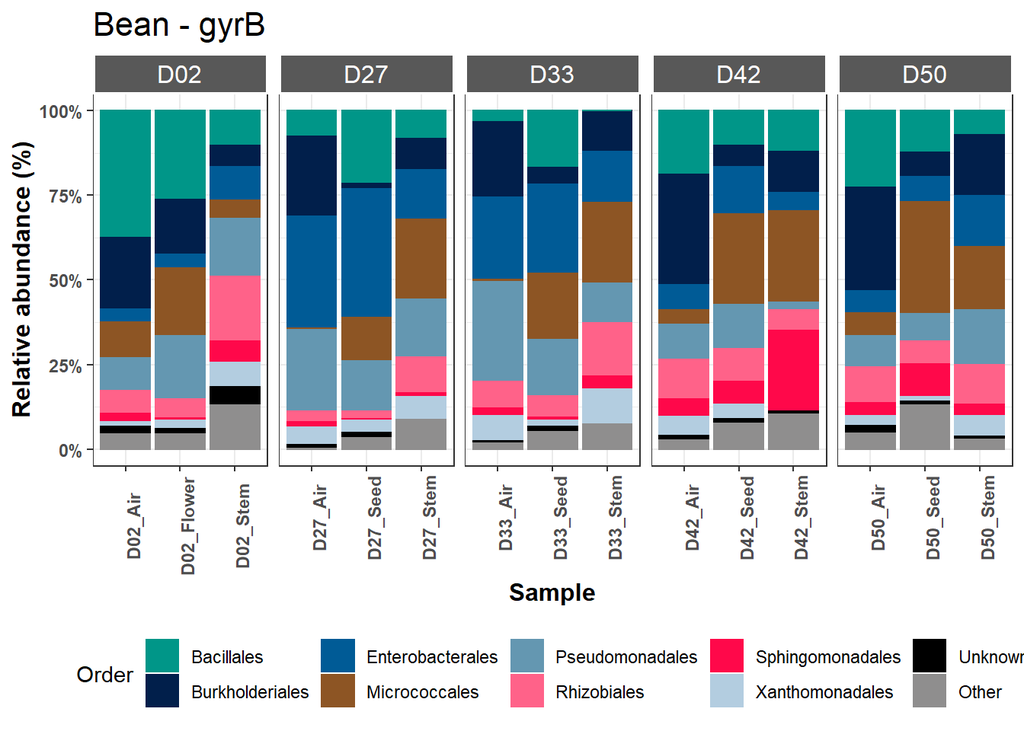

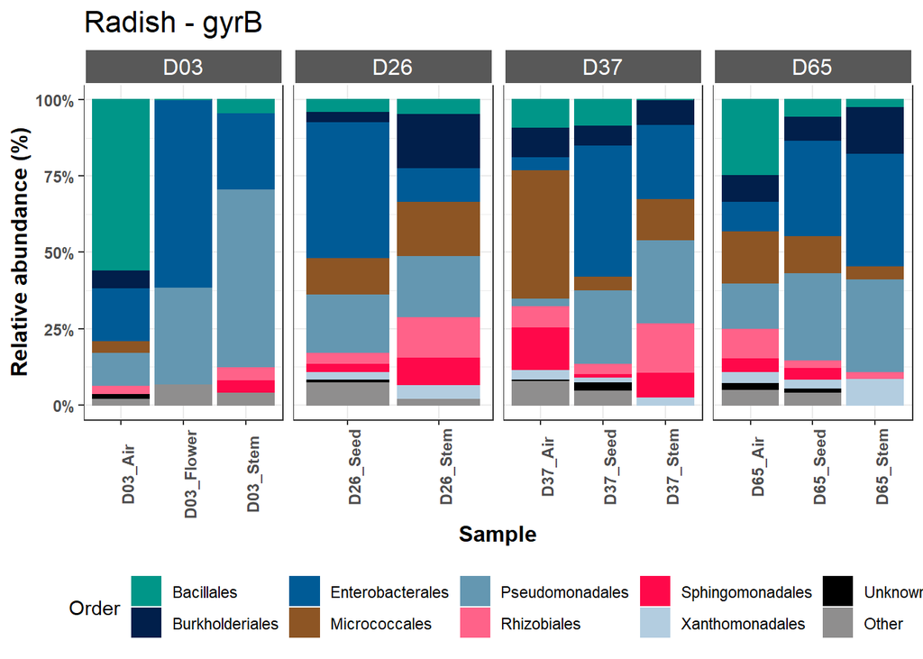

## 8.5 - Origin of seed-borne taxa

We performed analysis with gyrB since this marker is more resolutive than 16S

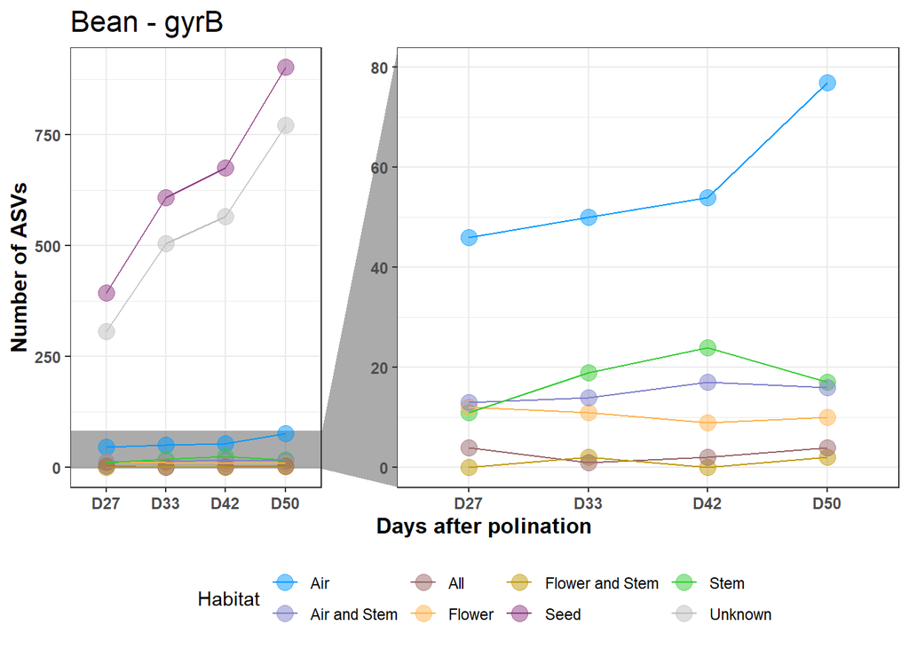

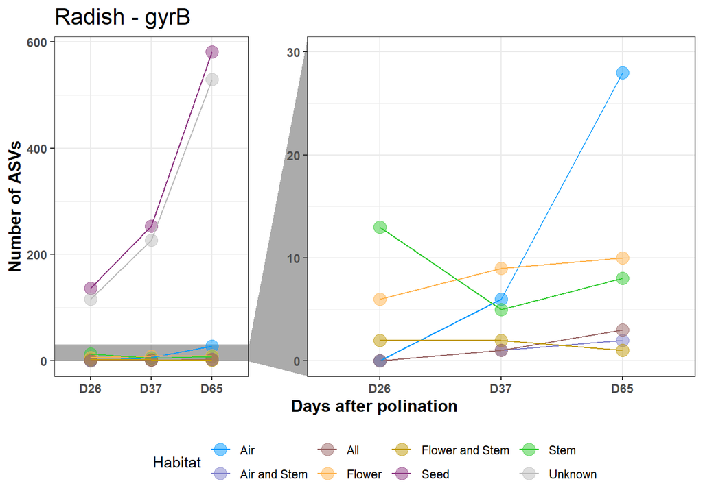

# 9 - Plant specific ASVs, origins

We select only ASVs significantly represented in individual plants : ASV1 (Bean and Radish), ASV2 (Bean), ASV5 (Bean), ASV11 (Bean)

## 9.1 - Origins

### 9.1.1- Prepare data

### 9.1.2 - Ternary plot

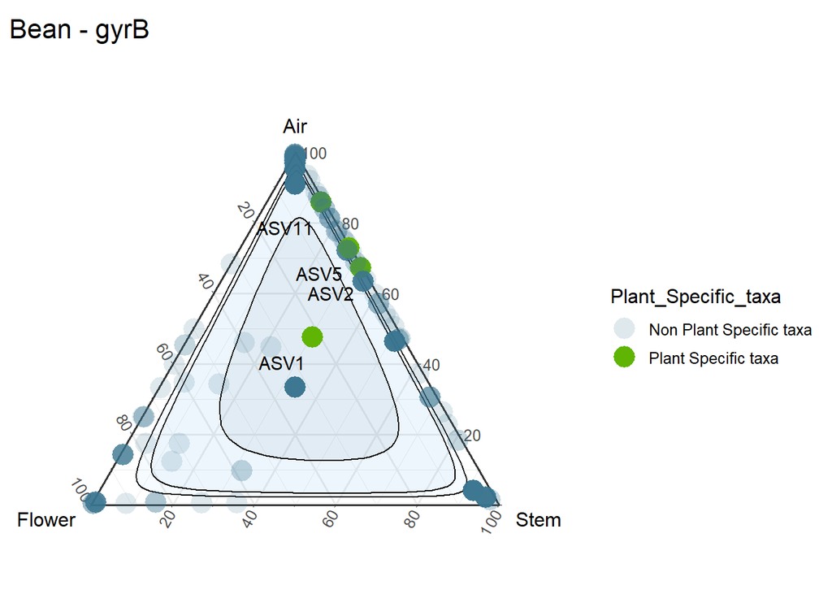

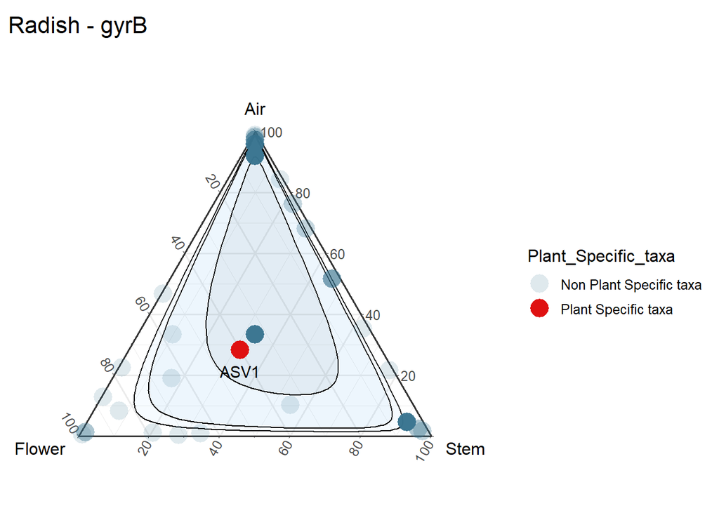

# 10 - Ecological processes QPE

To analyze ecological processes we worked on the agglomerate dataset (seed per individual plant, see part 7) though QPE framework (Stegen et al., 2013.)

## 10.1 - Prepare datasets

Agglomerate all seed at individual plant level.

Here all seed communities are agglomerate at the individual plant level using all taxa and not only the 1st rank taxa. Since taxa abundance is distorted by the synthetic media (as well as PCR amplification), we first transform taxa abundance in presence/absence by sample and then merged per plant.

Select seed only for each plant species at each sampling time

## 10.2 - Raup-Crick Index (RCI)

## 10.3 - Beta Nearest taxon Index (BNTI)

## 10.4 - Combine RCI and BNTI

## 10.5 - Plot QPE

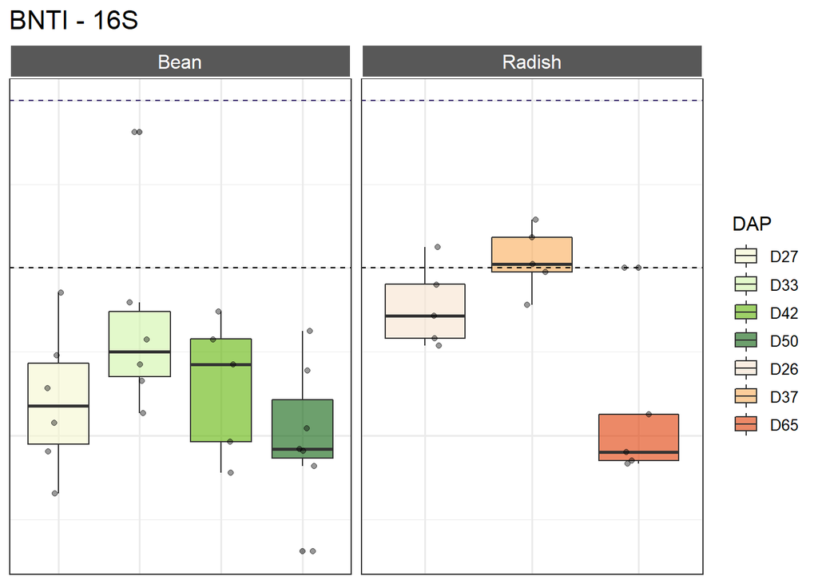

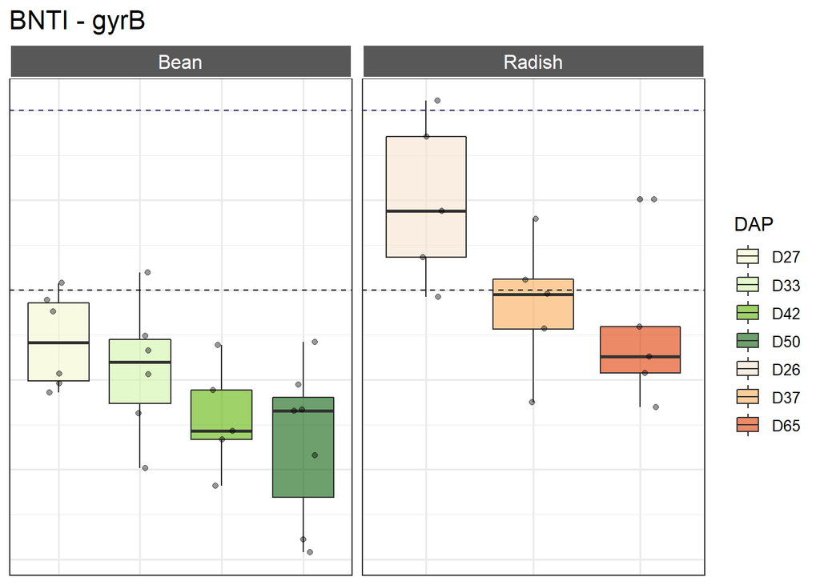

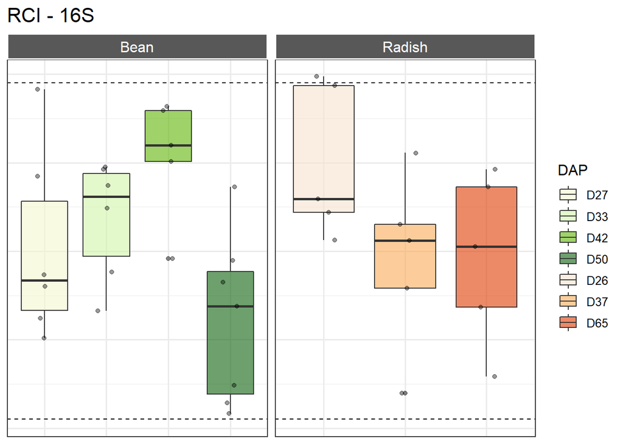

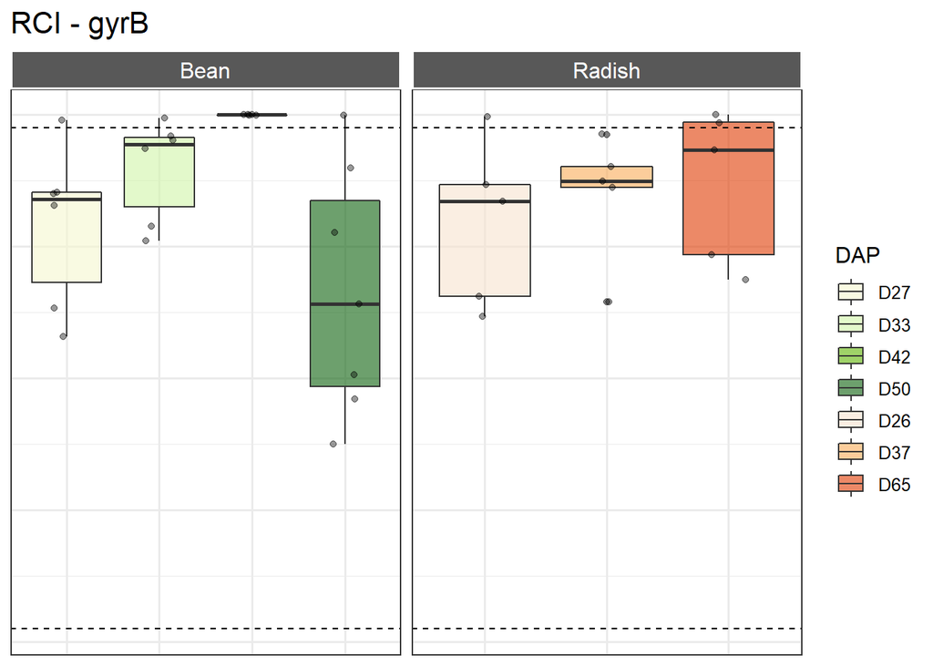

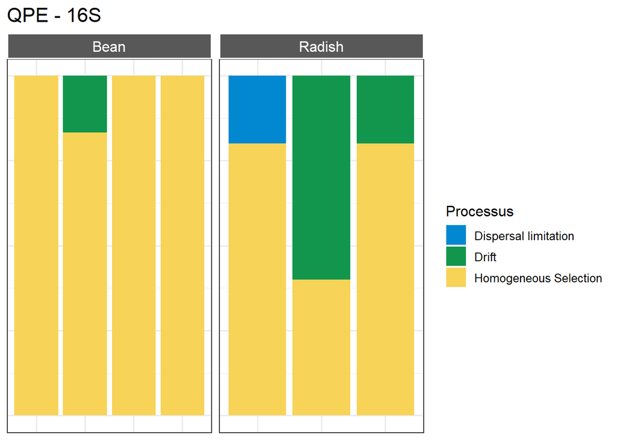

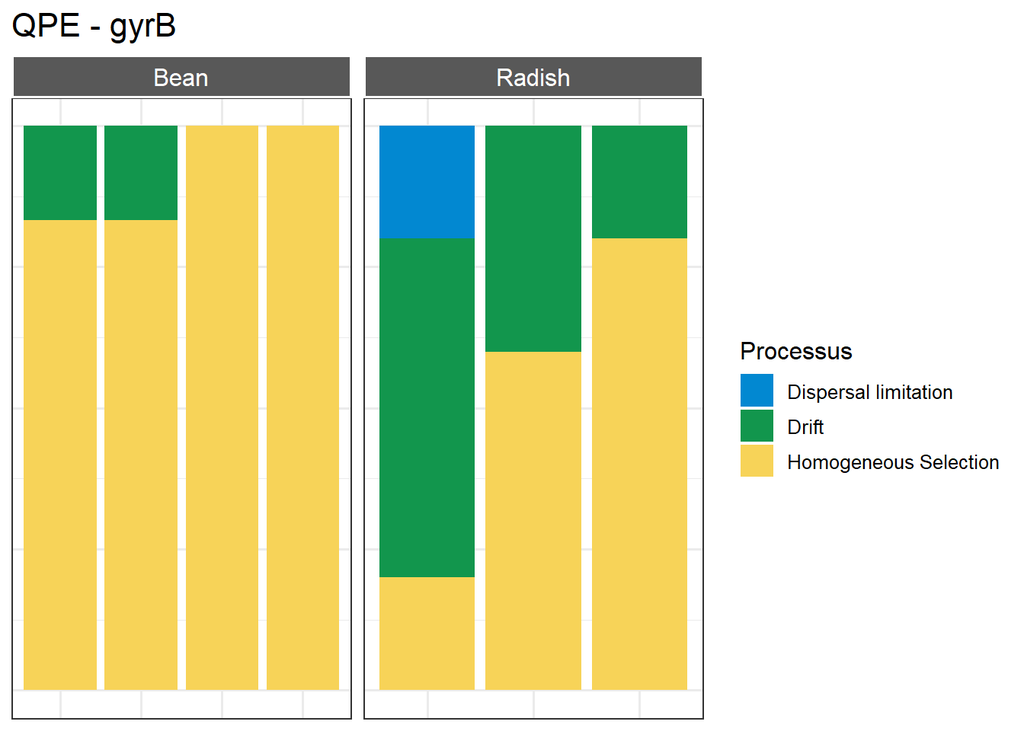

# End of script

Chesneau et al., 2021  
title: “Single seed microbiota: assembly and transmission from parent plant to seedling”